# BUAN 5310 Final EDA

Weihao Yuan (Melvin), Avanti Likhite, Ye Xu, Jingnan Yang

May 4, 2018

```r
#Please install this package

#install.packages("corrplot")
```

## BUAN 5310 Final Project EDA

```r
# load package
library(ggplot2)
library(ISLR)
library(gridExtra)
```

Data format looks good.

```r
#Load Data
dat <- read.csv("Mobile.csv", header = T, stringsAsFactors = FALSE)
dat$price_range <- as.factor(dat$price_range)
head(dat)
```

```
##   battery_power blue clock_speed dual_sim fc four_g int_memory m_dep
## 1           842    0         2.2        0  1      0          7   0.6
## 2          1021    1         0.5        1  0      1         53   0.7
## 3           563    1         0.5        1  2      1         41   0.9
## 4           615    1         2.5        0  0      0         10   0.8
## 5          1821    1         1.2        0 13      1         44   0.6
## 6          1859    0         0.5        1  3      0         22   0.7
##   mobile_wt n_cores pc px_height px_width  ram sc_h sc_w talk_time three_g
## 1       188       2  2        20      756 2549    9    7        19       0
## 2       136       3  6       905     1988 2631   17    3         7       1
## 3       145       5  6      1263     1716 2603   11    2         9       1
## 4       131       6  9      1216     1786 2769   16    8        11       1
## 5       141       2 14      1208     1212 1411    8    2        15       1
## 6       164       1  7      1004     1654 1067   17    1        10       1
##   touch_screen wifi price_range
## 1            0    1           1
## 2            1    0           2
## 3            1    0           2
## 4            0    0           2
## 5            1    0           1
## 6            0    0           1
```

```r
sum(is.na(dat))
```

```
## [1] 0
```

No mising Value – Great

```r
dim(dat)
```

```
## [1] 2000   21
```

This dataset contain 2000 observations and 21 variable

- Four price range is dependent variable. This indicates that there are four market niche. This is the target variable with value of 0(low cost), 1(medium cost), 2(high cost) and 3(very high cost).

Equal sample 500 from each market niche.

- Dummy varibles:
1. dual sim card: half and half
2. color of blue: 49.5% of cell phone has blue tooth. Really, half of the sample population? Okay…
3. four_g: 52.15%. half and half
4. 3g: 76.15% have 3g
5. touch-screen: 50.3% half and half
6. wifi: 50.7% are wifi support. half and half.

```r
summary(dat)
```

```
##  battery_power         blue        clock_speed       dual_sim
##  Min.   : 501.0   Min.   :0.000   Min.   :0.500   Min.   :0.0000
##  1st Qu.: 851.8   1st Qu.:0.000   1st Qu.:0.700   1st Qu.:0.0000
##  Median :1226.0   Median :0.000   Median :1.500   Median :1.0000
##  Mean   :1238.5   Mean   :0.495   Mean   :1.522   Mean   :0.5095
##  3rd Qu.:1615.2   3rd Qu.:1.000   3rd Qu.:2.200   3rd Qu.:1.0000
##  Max.   :1998.0   Max.   :1.000   Max.   :3.000   Max.   :1.0000
##        fc             four_g         int_memory        m_dep
##  Min.   : 0.000   Min.   :0.0000   Min.   : 2.00   Min.   :0.1000
##  1st Qu.: 1.000   1st Qu.:0.0000   1st Qu.:16.00   1st Qu.:0.2000
##  Median : 3.000   Median :1.0000   Median :32.00   Median :0.5000
##  Mean   : 4.309   Mean   :0.5215   Mean   :32.05   Mean   :0.5018
##  3rd Qu.: 7.000   3rd Qu.:1.0000   3rd Qu.:48.00   3rd Qu.:0.8000
##  Max.   :19.000   Max.   :1.0000   Max.   :64.00   Max.   :1.0000
##    mobile_wt        n_cores            pc           px_height
##  Min.   : 80.0   Min.   :1.000   Min.   : 0.000   Min.   :   0.0
##  1st Qu.:109.0   1st Qu.:3.000   1st Qu.: 5.000   1st Qu.: 282.8
##  Median :141.0   Median :4.000   Median :10.000   Median : 564.0
##  Mean   :140.2   Mean   :4.521   Mean   : 9.916   Mean   : 645.1
##  3rd Qu.:170.0   3rd Qu.:7.000   3rd Qu.:15.000   3rd Qu.: 947.2
##  Max.   :200.0   Max.   :8.000   Max.   :20.000   Max.   :1960.0
##     px_width           ram            sc_h            sc_w
##  Min.   : 500.0   Min.   : 256   Min.   : 5.00   Min.   : 0.000
##  1st Qu.: 874.8   1st Qu.:1208   1st Qu.: 9.00   1st Qu.: 2.000
##  Median :1247.0   Median :2146   Median :12.00   Median : 5.000
##  Mean   :1251.5   Mean   :2124   Mean   :12.31   Mean   : 5.767
##  3rd Qu.:1633.0   3rd Qu.:3064   3rd Qu.:16.00   3rd Qu.: 9.000
##  Max.   :1998.0   Max.   :3998   Max.   :19.00   Max.   :18.000
##    talk_time        three_g        touch_screen        wifi
##  Min.   : 2.00   Min.   :0.0000   Min.   :0.000   Min.   :0.000
##  1st Qu.: 6.00   1st Qu.:1.0000   1st Qu.:0.000   1st Qu.:0.000
##  Median :11.00   Median :1.0000   Median :1.000   Median :1.000
##  Mean   :11.01   Mean   :0.7615   Mean   :0.503   Mean   :0.507
##  3rd Qu.:16.00   3rd Qu.:1.0000   3rd Qu.:1.000   3rd Qu.:1.000
##  Max.   :20.00   Max.   :1.0000   Max.   :1.000   Max.   :1.000
##  price_range
##  0:500
##  1:500
##  2:500
##  3:500
##
##
```

quick plots for predictor

battery power seems matter 0, 1 &2, 3

clock speed doesn’t matter

fc Front Camera mega pixels doesn’t matter? Really. Look into this

Front Camera mega pixels doesn’t matter? Really. Look into this

Mobile Depth in cm doesn’t matter

Weight matter in range 3

Number of cores of processor not that matter

Primary Camera mega pixels doesn’t matter? Really. Look into this

height & width matter

ram definetly matter

screen height and width not matter

talk time matters, maybe.

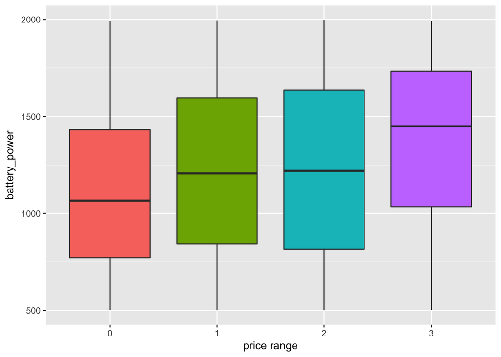

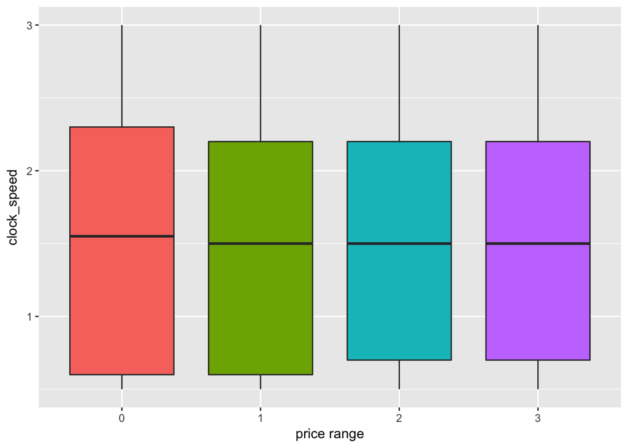

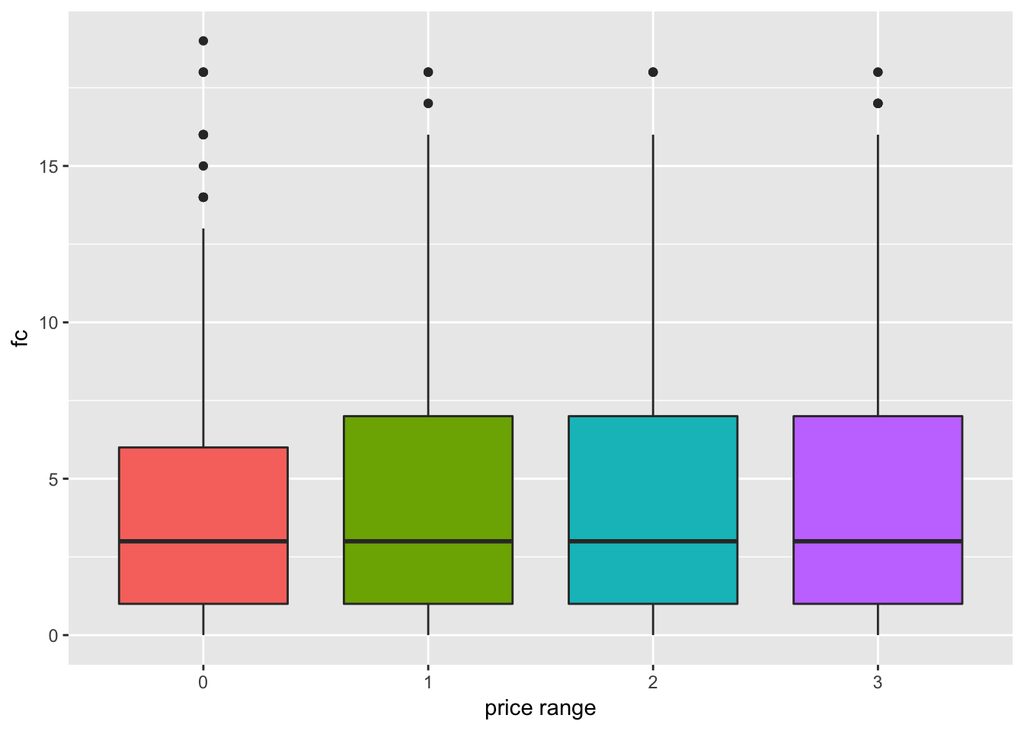

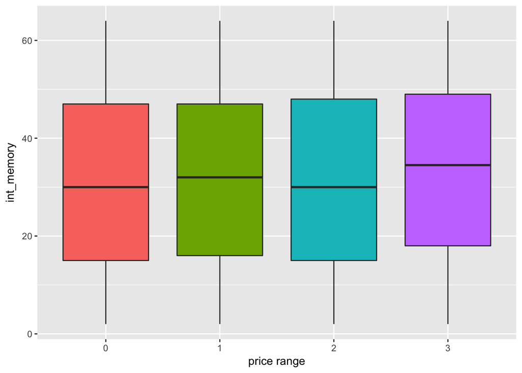

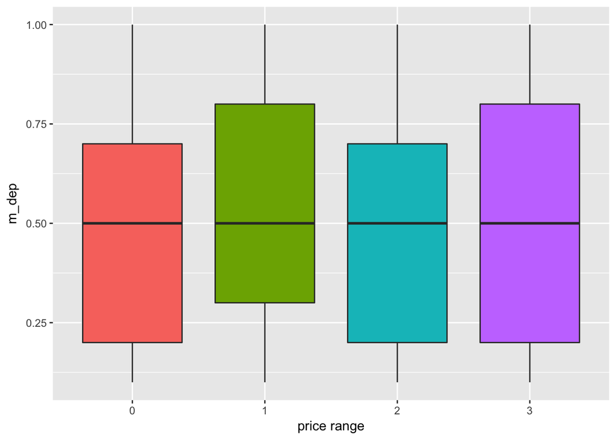

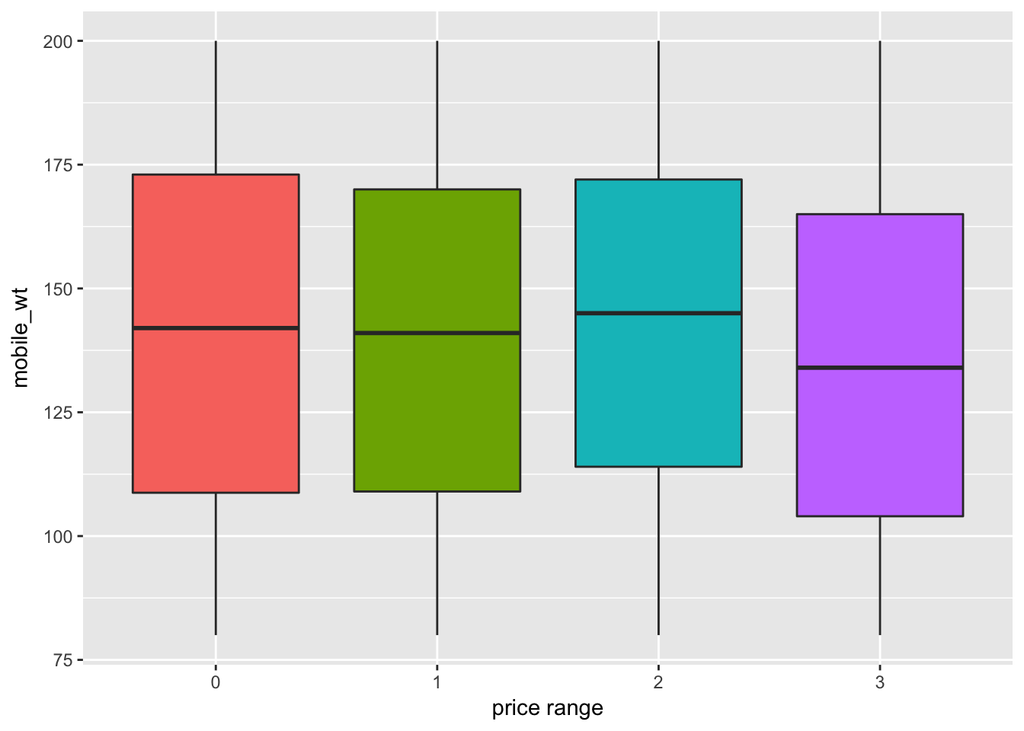

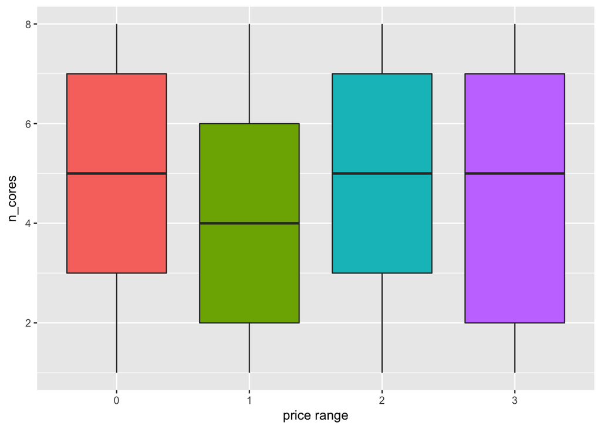

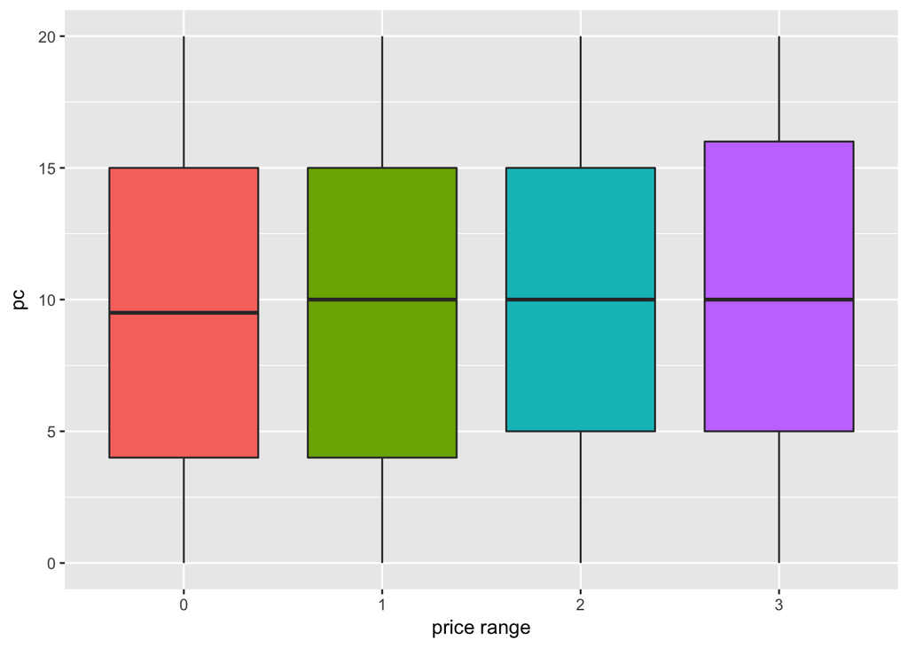

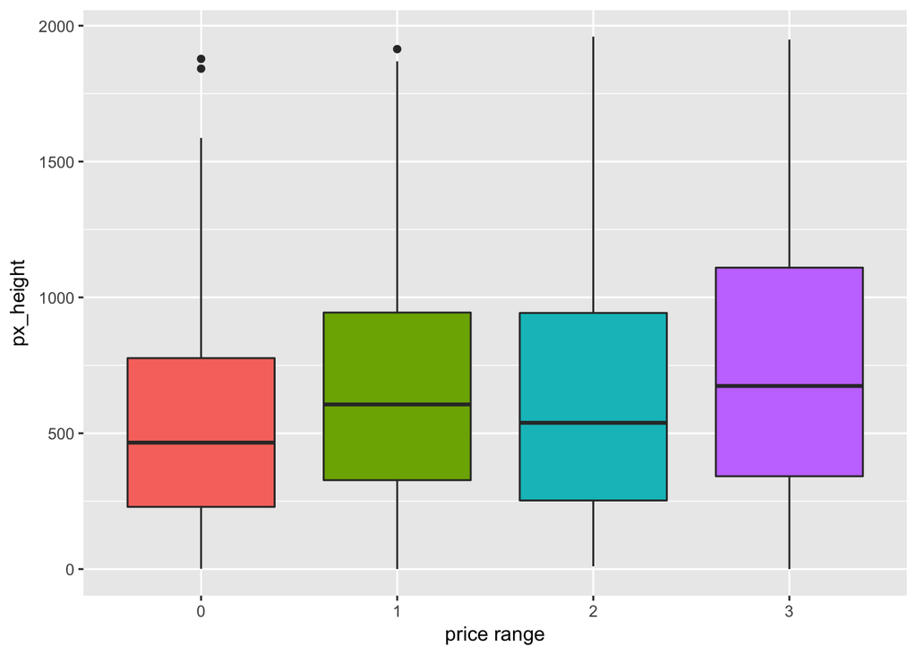

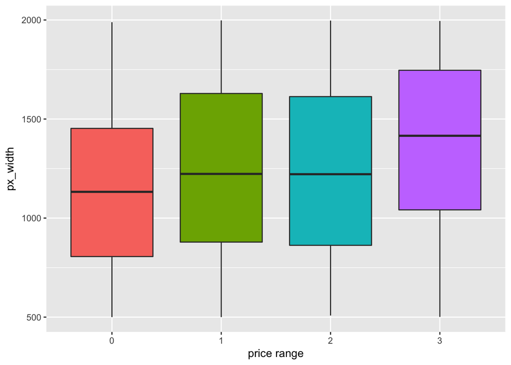

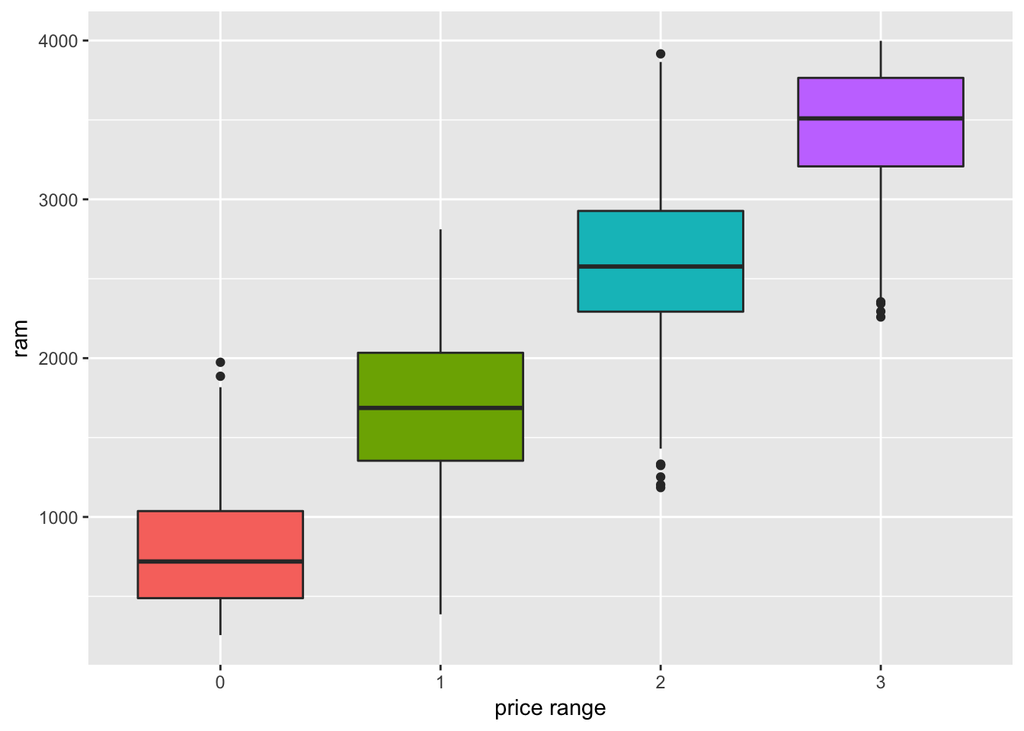

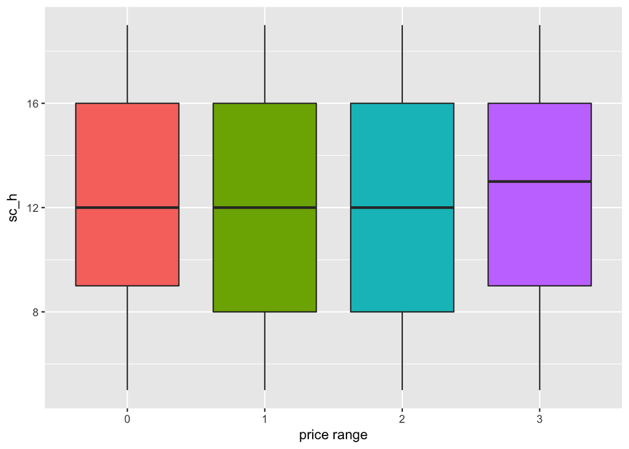

[2 more figures not shown]

```r
for(var in names(dat[,-c(2, 4, 6, 18, 19, 20, 21)])){
 print(qplot(x=dat$price_range, y=dat[,var], data = dat, fill=dat$price_range, geom='boxplot', ylab = var, xlab = "price range")+
         guides(fill=FALSE))
}
```

Correlaton:

3g is the base of 4g. It makes sense

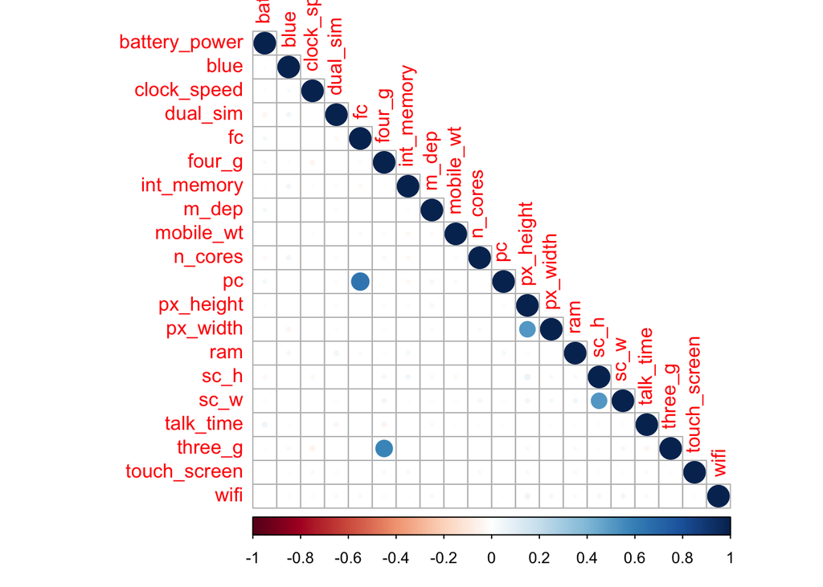

```r
library(corrplot)
dcor <- round(cor(dat[,-21]),2)
corrplot(dcor, method="circle",type="lower")
```

### ========================================================

## Start building models

1. LDA
2. QDA
3. KNN
4. Random Forest

```r
# Load library for model building
library(MASS)
library(leaps)
library(caret)
library(klaR)
## Split data
levels(dat$price_range)<- c("Class_0", "Class_1", "Class_2", "Class_3")

# define training and testing data
set.seed(998)
inTraining <- createDataPartition(dat$price_range, p = .8, list = FALSE)

# Use 80% of the original data as training set
training <- dat[ inTraining,]

# a set of predictor
training.x <-training[, c(1:(ncol(training)-1))]

# dependent variable
training.y <- training$price_range


# The remaining 20% as the test data set
# Pretend its the unknow data from the future
testing  <- dat[-inTraining,]
```

### Stepwise model selection for LDA, QDA

```r
# Set up 10-folds cross validation to select the best predictors for LDA AND QDA
cctrl1 <- trainControl(method = "cv",
                       number = 10, # 10-fold CV
                       returnResamp = "all",
                       classProbs = TRUE)
```

```r
# Set up bootstrap cross validation to select the best predictors for LDA AND QDA
#cctrl2 <- trainControl(method = "boot",
#                       number = 10, # number of resampling iterations
#                       returnResamp = "all",
#                       classProbs = TRUE)
# We also use bootstrap cv and compare the result with 10-folds cv. They both yield the same result
# So we are not running this chunk of code for the sake of running time
```

#### LDA with stepwise selection

```r
step.lda$results$Accuracy
```

```
## [1] 0.904375
```

```r
lda_error_rate <- 1- step.lda$results$Accuracy
lda_error_rate
```

```
## [1] 0.095625
```

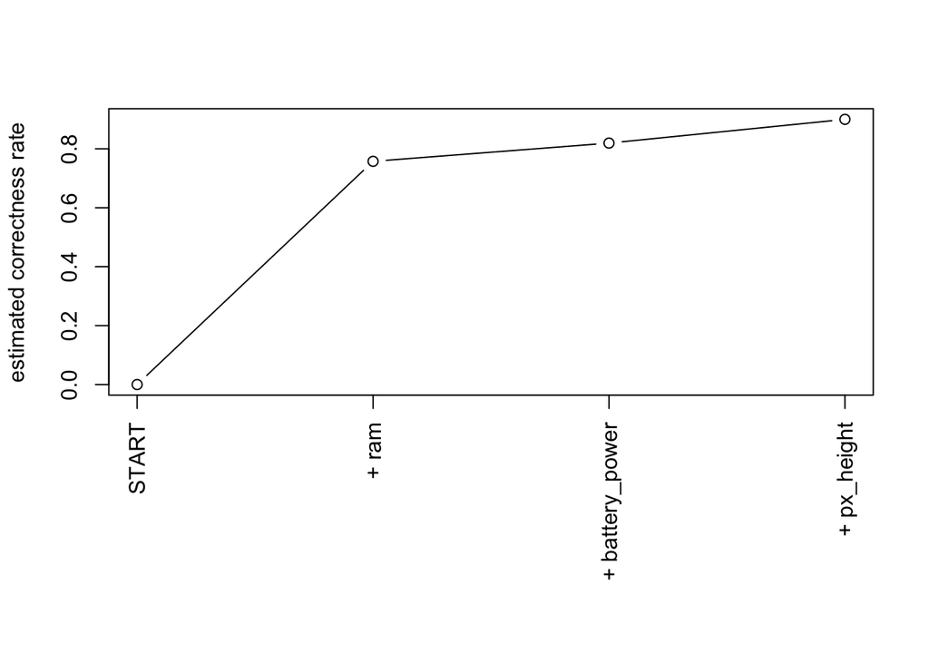

```r
plot(step.lda$finalModel)
```

```r
# using bootstrap cv to select the optimal predictors
# set.seed(998)
# step.lda.2 <- train(training.x, training.y,
#                      method = "stepLDA", #Linear Discriminant Analysis with Stepwise Feature Selection
#                      trControl = cctrl2,
#                     metric = "Accuracy",
#                      preProc = c("center", "scale"))
# We also use bootstrap cv and compare the result with 10-folds cv. They both yield the same result
# So we are not running this chunk of code for the sake of running time
```

#### QDA with stepwise selection

```r
step.qda$results$Accuracy
```

```
## [1] 0.909375
```

```r
qda_error_rate <- 1- step.qda$results$Accuracy
qda_error_rate
```

```
## [1] 0.090625
```

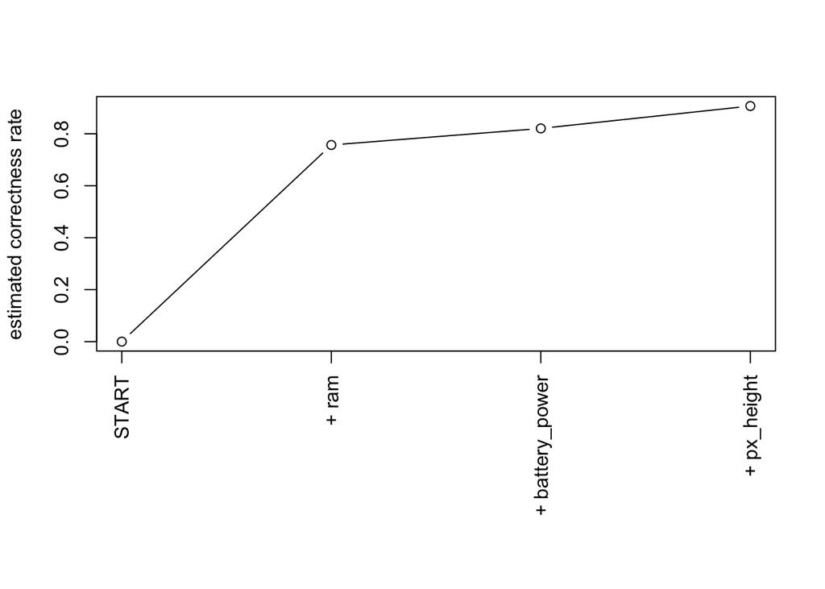

```r
plot(step.qda$finalModel)
```

```r
# Similar to lda model
```

#### Find the best k size (neighborhood size) using 10 fold-CV errors.

```r
# write function to select best k
cv.knn<- function (dataY, dataX, kn=1, K=10, seed=998) {
  n <- nrow(dataX)
  set.seed(seed)
  library(class)

  f <- ceiling(n/K)
  s <- sample(rep(1:K, f), n)

  CV=NULL;PvsO=NULL

  for (i in 1:K) {
    test.index <- seq_len(n)[(s == i)] #test data
    train.index <- seq_len(n)[(s != i)] #training data

    train.X <- dataX[train.index,]
    test.X <- dataX[test.index,]
    train.y <- dataY[train.index]
    test.y <- dataY[test.index]
    #predicted test set y
    knn.pred=knn(train.X, test.X, train.y, k=kn)
    #observed - predicted on test data
    error= mean(knn.pred!=test.y)
    #error rates
    CV=c(CV,mean(error))
    predvsobs=data.frame(knn.pred,test.y)
    PvsO=rbind(PvsO,predvsobs)
  }

  #Output
  list(k = K,
       knn_error_rate = mean(CV), confusion=table(PvsO[,1],PvsO[,2]), seed=seed)
}
```

```r
cv.error=NULL
for (i in 1:100) {
  cv.error[i] <- cv.knn(dataY=training.y, dataX=training.x, kn=i,
                        K=10, seed=998)$knn_error_rate

}
k=which(cv.error==min(cv.error)) # the best k with least cv testing error
print(k)
```

```
## [1] 19
```

```r
knn_error_rate=cv.knn(dataY=training.y, dataX=training.x, kn=k, K=10, seed=998)
knn_error_rate
```

```
## $k
## [1] 10
##
## $knn_error_rate
## [1] 0.06625
##
## $confusion
##
##           Class_0 Class_1 Class_2 Class_3
##   Class_0     393      19       0       0
##   Class_1       7     363      18       0
##   Class_2       0      18     364      26
##   Class_3       0       0      18     374
##
## $seed
## [1] 998
```

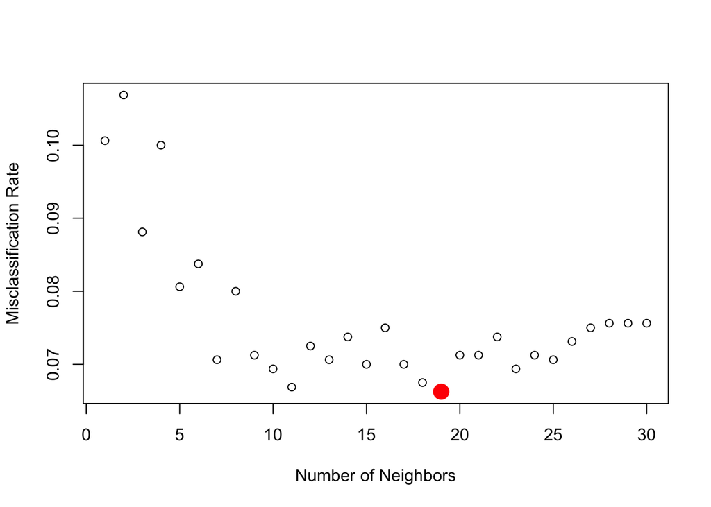

```r
plot(cv.error[1:30], xlab = "Number of Neighbors", ylab = "Misclassification Rate",
     col=ifelse(cv.error[1:30] == min(cv.error[1:30]), "red", "black"),
     pch = ifelse(cv.error[1:30] == min(cv.error[1:30]), 19, 1),
     cex = ifelse(cv.error[1:30] == min(cv.error[1:30]), 2, 1))
```

#### Decision tree

```
##    battery_power blue clock_speed dual_sim fc four_g int_memory m_dep
## 7           1821    0         1.7        0  4      1         10   0.8
## 9           1445    1         0.5        0  0      0         53   0.7
## 12          1520    1         2.2        0  5      1         33   0.5
## 14           803    1         2.1        0  7      0         17   1.0
## 18           595    0         0.9        1  7      1         23   0.1
## 22          1709    1         2.1        0  1      0         13   1.0
##    mobile_wt n_cores pc px_height px_width  ram sc_h sc_w talk_time
## 7        139       8 10       381     1018 3220   13    8        18
## 9        174       7 14       386      836 1099   17    1        20
## 12       177       8 18       151     1005 3826   14    9        13
## 14       198       4 11       344     1440 2680    7    1         4
## 18       121       3 17       441      810 3752   10    2        18
## 22       156       2  2       974     1385 3283   17    1        15
##    three_g touch_screen wifi price_range
## 7        1            0    1     Class_3
## 9        1            0    0     Class_0
## 12       1            1    1     Class_3
## 14       1            0    1     Class_2
## 18       1            1    0     Class_3
## 22       1            0    0     Class_3
```

```
##
## Classification tree:
## tree(formula = factor(price_range) ~ ., data = train)
## Variables actually used in tree construction:
## [1] "ram"           "px_height"     "battery_power" "px_width"
## Number of terminal nodes:  16
## Residual mean deviance:  0.7038 = 777 / 1104
## Misclassification error rate: 0.1375 = 154 / 1120
```

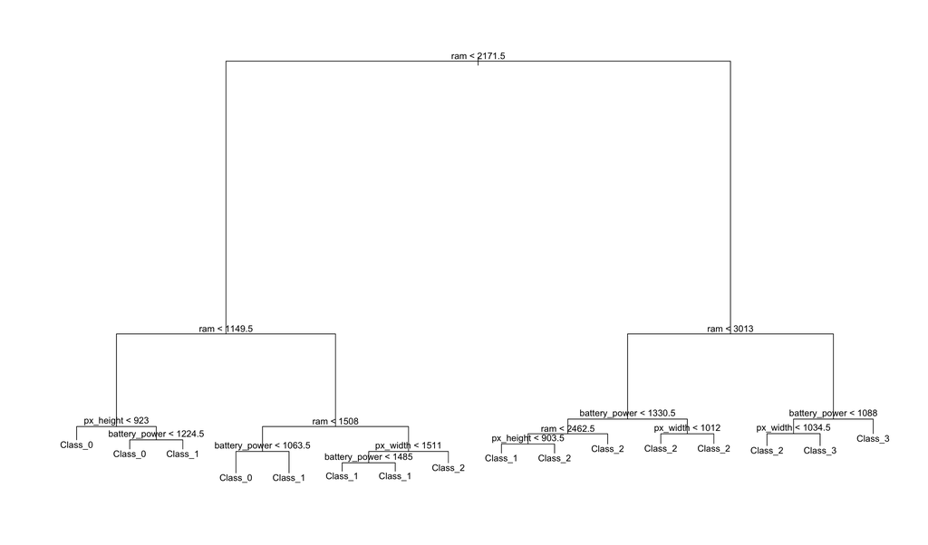

```
## [1] 0.2145833
```

```
## [1] 0.7854167
```

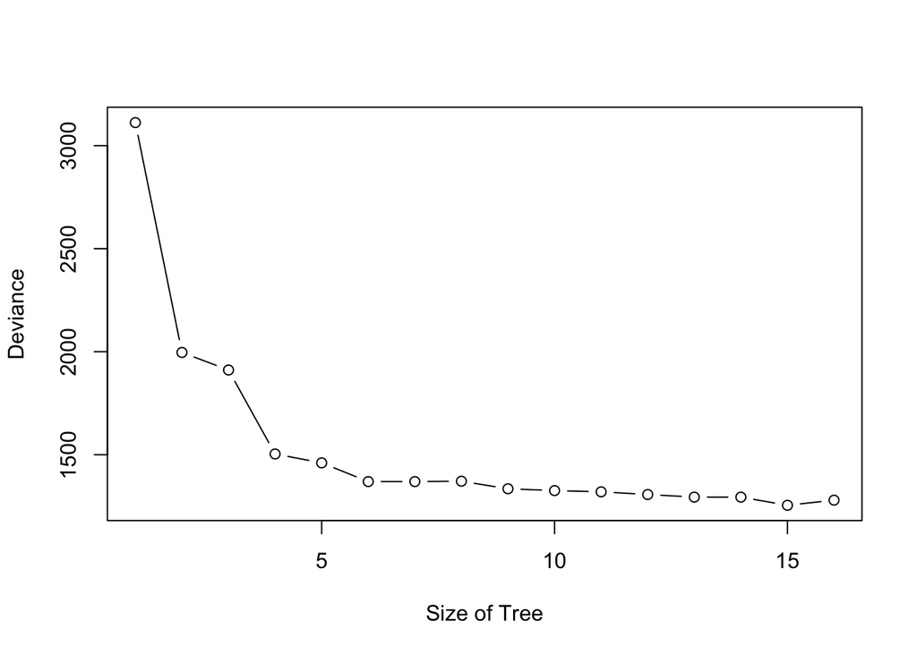

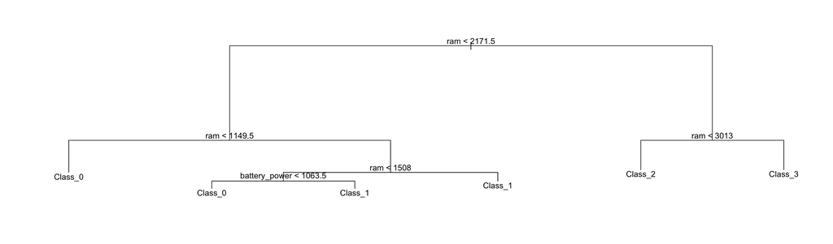

```r
summary(prune.Model_1)
```

```
##
## Classification tree:
## snip.tree(tree = Model_1, nodes = c(11L, 4L, 7L, 6L))
## Variables actually used in tree construction:
## [1] "ram"           "battery_power"
## Number of terminal nodes:  6
## Residual mean deviance:  1.084 = 1207 / 1114
## Misclassification error rate: 0.1991 = 223 / 1120
```

##### Confusion matrix for pruned tree

```
##
## prune.predict Class_0 Class_1 Class_2 Class_3
##       Class_0     110      23       0       0
##       Class_1      11      69      28       0
##       Class_2       0      21      82      17
##       Class_3       0       0      14     105
```

```
## [1] 0.2375
```

```
## [1] 0.7625
```

##### Random Forest

```
##                 Length Class  Mode
## call               5   -none- call
## type               1   -none- character
## predicted       1120   factor numeric
## err.rate        2500   -none- numeric
## confusion         20   -none- numeric
## votes           4480   matrix numeric
## oob.times       1120   -none- numeric
## classes            4   -none- character
## importance       120   -none- numeric
## importanceSD     100   -none- numeric
## localImportance    0   -none- NULL
## proximity          0   -none- NULL
## ntree              1   -none- numeric
## mtry               1   -none- numeric
## forest            14   -none- list
## y               1120   factor numeric
## test               0   -none- NULL
## inbag              0   -none- NULL
## terms              3   terms  call
```

##### Confusion matrix for bagged tree

```
##
## bag.Model_1_predict Class_0 Class_1 Class_2 Class_3
##             Class_0     107      10       0       0
##             Class_1      14     100      15       0
##             Class_2       0       3     105      13
##             Class_3       0       0       4     109
```

```
## [1] 0.1229167
```

```
## [1] 0.8770833
```

```
##                   Class_0    Class_1    Class_2     Class_3
## battery_power 19.37425413 21.0178051 16.5503962 21.37116318
## blue          -1.38160321  0.5104064  0.1324553  0.78442888
## clock_speed   -0.60902721 -2.6099789 -1.5021900  0.15416515
## dual_sim      -0.57542594  0.3716470  1.0953469  0.81594454
## fc             1.49975203 -2.0457461  0.6840094  0.02695505
## four_g         0.32513522 -1.3682740 -0.3914853  0.85334373
## int_memory    -0.57585520 -2.2346883 -1.7242556  2.13035104
## m_dep          0.04401857  0.4304743  0.6392756 -0.54362190
## mobile_wt     -1.76307452  3.0084315  0.7695692  2.86132657
## n_cores       -0.16272573  2.3801031  0.7158144 -0.50426107
## pc             1.42731046  0.4759486 -1.4154291  0.35387471
## px_height     16.40172399 13.0114805 13.7670427  5.95479265
## px_width      11.74407503 11.8434547 14.3099100  7.74592329
## ram           88.19543356 64.7887049 62.1608381 85.54211551
## sc_h           1.40060230  0.3098875  2.1296299  1.21377257
## sc_w          -0.40926864 -0.1147657 -0.3323164  2.41698621
## talk_time      2.37266246  1.7451911  0.4523729 -1.26911804
## three_g        1.89468904  1.8196313 -0.9025078 -1.48151406
## touch_screen  -1.25112214  0.6419863 -1.9166920  1.13621188
## wifi           0.38932277 -1.0129717 -0.8431220 -0.52488358
##               MeanDecreaseAccuracy MeanDecreaseGini
## battery_power          31.65491302        58.900337
## blue                    0.17388717         5.817395
## clock_speed            -2.32523369        23.955873
## dual_sim                0.94212599         6.223286
## fc                     -0.01208908        21.337181
## four_g                 -0.35125776         5.910659
## int_memory             -1.18249434        31.812883
## m_dep                   0.27501590        21.061361
## mobile_wt               2.53788345        34.608033
## n_cores                 1.29366150        19.845235
## pc                      0.39886808        24.894851
## px_height              22.43499918        49.134996
## px_width               20.87681831        49.400905
## ram                    93.04059410       393.911336
## sc_h                    2.59467750        24.550861
## sc_w                    0.63682699        24.771188
## talk_time               1.70383945        26.633500
## three_g                 0.85235564         4.494764
## touch_screen           -0.81354459         6.290744
## wifi                   -1.09382096         5.507909
```

##### Confusion Matrix for Random Forest

```
##
## rf.Model_1.predict Class_0 Class_1 Class_2 Class_3
##            Class_0     112      13       0       0
##            Class_1       9      93      22       0
##            Class_2       0       7      99       9
##            Class_3       0       0       3     113
```

```
##                 Length Class  Mode
## call               5   -none- call
## type               1   -none- character
## predicted       1120   factor numeric
## err.rate        2500   -none- numeric
## confusion         20   -none- numeric
## votes           4480   matrix numeric
## oob.times       1120   -none- numeric
## classes            4   -none- character
## importance       120   -none- numeric
## importanceSD     100   -none- numeric
## localImportance    0   -none- NULL
## proximity          0   -none- NULL
## ntree              1   -none- numeric
## mtry               1   -none- numeric
## forest            14   -none- list
## y               1120   factor numeric
## test               0   -none- NULL
## inbag              0   -none- NULL
## terms              3   terms  call
```

```
##
## rf.Model_1.predict Class_0 Class_1 Class_2 Class_3
##            Class_0     112      13       0       0
##            Class_1       9      93      22       0
##            Class_2       0       7      99       9
##            Class_3       0       0       3     113
```

```r
mean(rf.Model_1.predict !=test[['price_range',exact=FALSE]])
```

```
## [1] 0.13125
```

```r
mean(rf.Model_1.predict ==test[['price_range',exact=FALSE]])
```

```
## [1] 0.86875
```

```r
cv.randomforest <-
  function (data, model= price_range~., yname="price_range", K=10, seed=998) {
    n <- nrow(data)
    set.seed(seed)

    datay=data[,yname] #response variable
    library(tree)
    #partition the data into K subsets
    f <- ceiling(n/K)
    s <- sample(rep(1:K, f), n)
    #generate indices 1:10 and sample n of them
    # K fold cross-validated error

    CV=NULL

    for (i in 1:K) { #i=1
      test.index <- seq_len(n)[(s == i)] #test data
      train.index <- seq_len(n)[(s != i)] #training data

      #model with training data
      rf.Model_1 = randomForest(model, data[train.index,],importance=TRUE,mtry=sqrt(13))
      #observed test set y
      y <- data[test.index, yname]
      #predicted test set y
      predy=predict(rf.Model_1, newdata = data[test.index,], type = "class")

      #observed - predicted on test data
      error= mean(predy != y)
      #error rates
      CV=c(CV,error)
    }
    #Output
    list(call = model, K = K,
         randomforest_error_rate = mean(CV), seed = seed)
  }
```

```r
er_random= cv.randomforest(data=training, model=price_range~., yname="price_range", K=10, seed=998)
er_random$randomforest_error_rate
```

```
## [1] 0.10875
```

After comparing the cross validation error for all the 4 models, we think knn is the best model. We apply the best model to the testing data we set aside in the beginning of our analysis.

```r
knn.pred = knn(training.x, testing[,-ncol(testing)], training.y, k = 19)
table(knn.pred, testing$price_range)
```

```
##
## knn.pred  Class_0 Class_1 Class_2 Class_3
##   Class_0      97       3       0       0
##   Class_1       3      95       8       0
##   Class_2       0       2      87       7
##   Class_3       0       0       5      93
```

```r
mean(knn.pred != testing$price_range)
```

```
## [1] 0.07
```

### ==============================================================

### Code below is draft. We don’t really need it.

### Just leave here to prove we did some work

### ==============================================================

# Use Cross-Validation with QDA, choosing only three variables

```
#Load Library
library(MASS)
#partition the data into K subsets
f <- ceiling(n/K)
s <- sample(rep(1:K, f), n)
#generate indices 1:10 and sample n of them
# K fold cross-validated error

CV=NULL

for (i in 1:K) { #i=1
  train.index <- seq_len(n)[(s != i)] #training data
  test.index <- seq_len(n)[(s == i)] #test data


  #model with training data
  qda.fit=qda(model, data=data[train.index,])
  #observed test set y
  qda.y <- data[test.index, yname]
  #predicted test set y
  qda.predy=predict(qda.fit, data[test.index,])$class

  #observed - predicted on test data
  error= mean(qda.y!=qda.predy)
  #error rates
  CV=c(CV,error)
}
#Output
list(call = model, K = K,
     qda_error_rate = mean(CV))
```

}

```
mean.qda.error <- c()

for(i in 1:1000){
  fun <- cv.qda(dat, model=price_range ~ ram + battery_power+ px_height, yname="price_range", K=10)

  mean.qda.error[i] <- fun$qda_error_rate
}

#Output
mean(mean.qda.error)
```

}

# mean.qda.error(times = 1000)

# LDA with stepwise selection

```
#Load Library
library(MASS)
#partition the data into K subsets
f <- ceiling(n/K)
s <- sample(rep(1:K, f), n)
#generate indices 1:10 and sample n of them
# K fold cross-validated error

CV=NULL

for (i in 1:K) { #i=1
  train.index <- seq_len(n)[(s != i)] #training data
  test.index <- seq_len(n)[(s == i)] #test data


  #model with training data
  lda.fit=lda(model, data=data[train.index,])
  #observed test set y
  lda.y <- data[test.index, yname]
  #predicted test set y
  lda.predy=predict(lda.fit, data[test.index,])$class

  #observed - predicted on test data
  error= mean(lda.y!=lda.predy)
  #error rates
  CV=c(CV,error)
}
#Output
list(call = model, K = K,
     lda_error_rate = mean(CV))
```

# }

mean.lda.error <- function(times = 1000){

```
mean.lda.error <- c()

for(i in 1:1000){
  fun <- cv.lda(dat, model=price_range ~ ram + battery_power+ px_height, yname="price_range", K=10)

  mean.lda.error[i] <- fun$lda_error_rate
}

#Output
mean(mean.lda.error)
```

}

mean.lda.error(times = 1000)

# This function allow the predict() apply on regsubsets class

cv.errors